# Part 1: Non-SMI (PMS 2007 Analysis)

## 2.4 Employment Status

Over half of those surveyed indicated they were in employment (53.5%), with more than a third indicating they were economically inactive (43.9%).

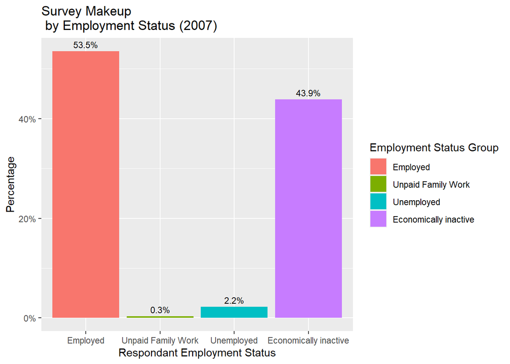

```r
# Employement Status
ggplot(data = subset_pms07, aes(x = employstat,
                          y = prop.table(stat(count)),
                          fill = employstat,
                          label = scales::percent(prop.table(stat(count))))) +
    geom_bar() +
    geom_text(stat = 'count',
              position = position_dodge(.9),
              vjust = -0.5,
              size = 3) +
    scale_y_continuous(labels = scales::percent) +
    labs(title="Survey Makeup \n by Employment Status (2007)",
       x = 'Respondant Employment Status',
       y = 'Percentage', fill = 'Employment Status Group')
```

## 2.5 Income Quintile

The majority of those surveyed did not answer, or their data was missing (20.6%), with the 3rd highest income quintile being the most indicated next (16.7%).

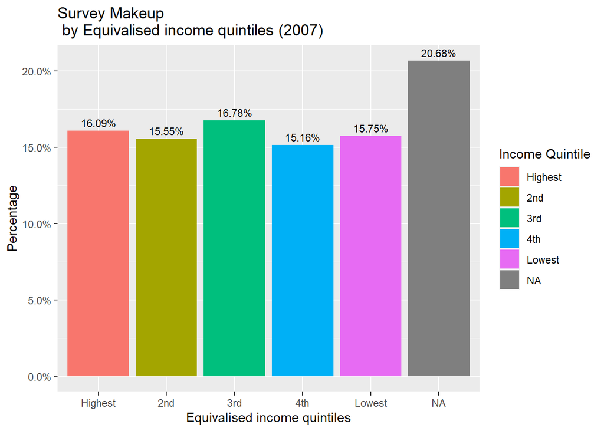

```r
# Equivalised income quintiles
ggplot(data = subset_pms07, aes(x = eqhouseinc,
                          y = prop.table(stat(count)),
                          fill = eqhouseinc,
                          label = scales::percent(prop.table(stat(count))))) +
    geom_bar() +
    geom_text(stat = 'count',
              position = position_dodge(.9),
              vjust = -0.5,
              size = 3) +
    scale_y_continuous(labels = scales::percent) +
    labs(title="Survey Makeup \n by Equivalised income quintiles (2007)",
       x = 'Equivalised income quintiles',
       y = 'Percentage', fill = 'Income Quintile')
```

## 2.6 Ethnic Group

The largest portion of the survey identified as White British (87.7%), with White (Non-British) being the next most common (4.1%).

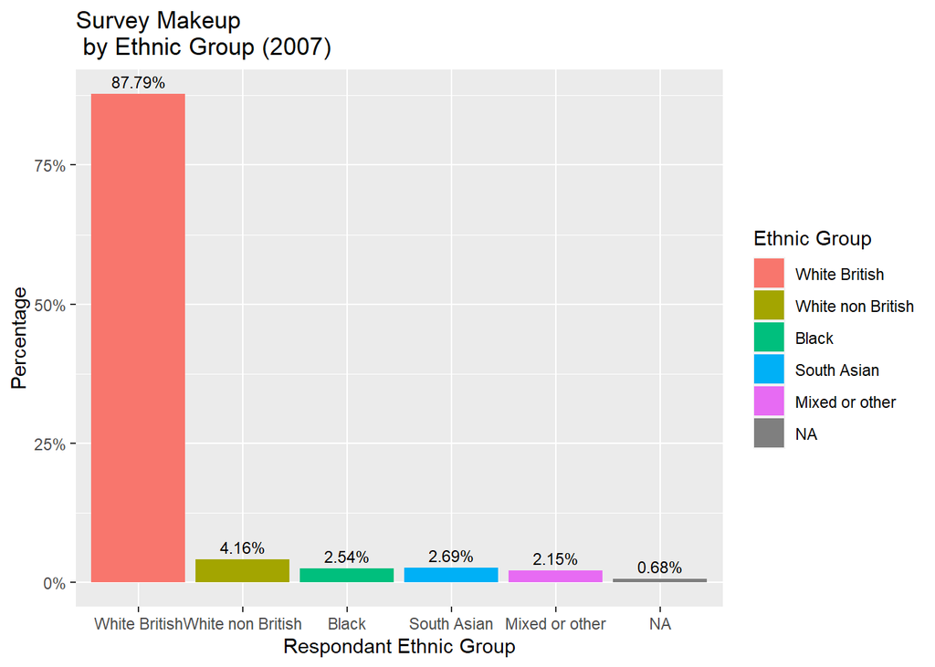

```r
# Ethnic Group
ggplot(data = subset_pms07, aes(x = ethnicgrp,
                          y = prop.table(stat(count)),
                          fill = ethnicgrp,
                          label = scales::percent(prop.table(stat(count))))) +
    geom_bar() +
    geom_text(stat = 'count',
              position = position_dodge(.9),
              vjust = -0.5,
              size = 3) +
    scale_y_continuous(labels = scales::percent) +
    labs(title="Survey Makeup \n by Ethnic Group (2007)",
       x = 'Respondant Ethnic Group',
       y = 'Percentage', fill = 'Ethnic Group')
```

## 2.7 Qualifications

The majority of the sample indicated having no qualifications (30.8%), with those having earned GCSE’s or eqivilant the next most common (24.5%).

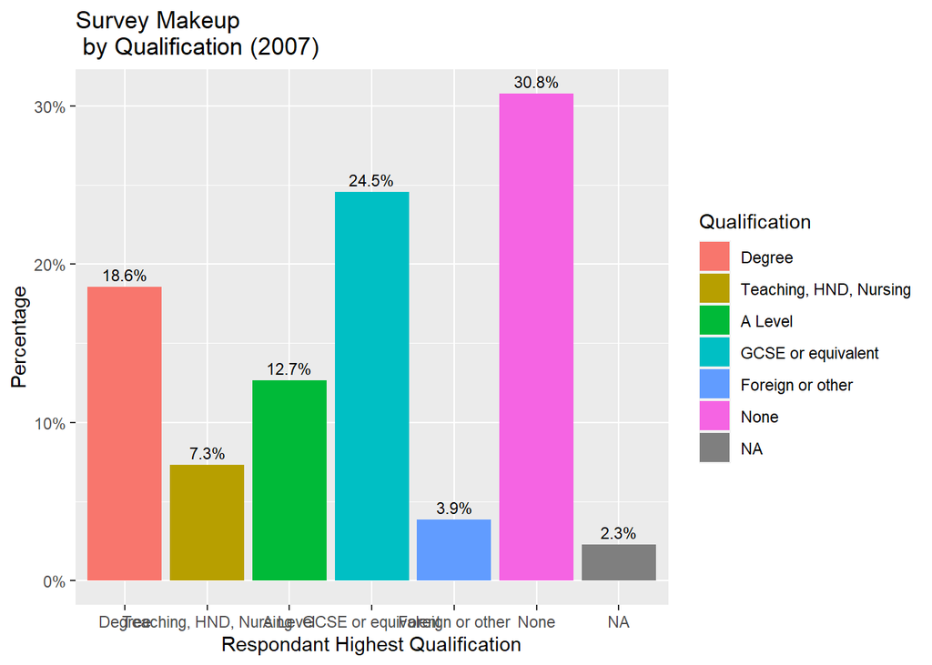

```r
# Highest Qualification
ggplot(data = subset_pms07, aes(x = hiqual,
                          y = prop.table(stat(count)),
                          fill = hiqual,
                          label = scales::percent(prop.table(stat(count))))) +
    geom_bar() +
    geom_text(stat = 'count',
              position = position_dodge(.9),
              vjust = -0.5,
              size = 3) +
    scale_y_continuous(labels = scales::percent) +
    labs(title="Survey Makeup \n by Qualification (2007)",
       x = 'Respondant Highest Qualification',
       y = 'Percentage', fill = 'Qualification')
```

## 2.8 Marital Status

Most of the sample were married (47.5%), with the next most common status being single (19.2%).

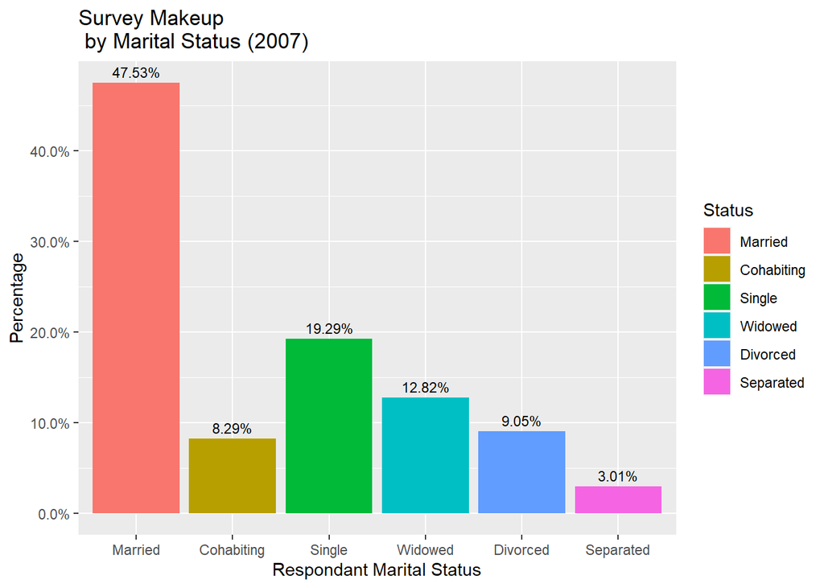

```r
# Marital Status
ggplot(data = subset_pms07, aes(x = maritalstat,
                          y = prop.table(stat(count)),
                          fill = maritalstat,
                          label = scales::percent(prop.table(stat(count))))) +
    geom_bar() +
    geom_text(stat = 'count',
              position = position_dodge(.9),
              vjust = -0.5,
              size = 3) +
    scale_y_continuous(labels = scales::percent) +
    labs(title="Survey Makeup \n by Marital Status (2007)",
       x = 'Respondant Marital Status',
       y = 'Percentage', fill = 'Status')
```

## 2.9 Number of CMDs

Most of the sample indicated no CMDs (83%), with 14% indicating one CMD and 3% indicating having two or more concurring CMDs.

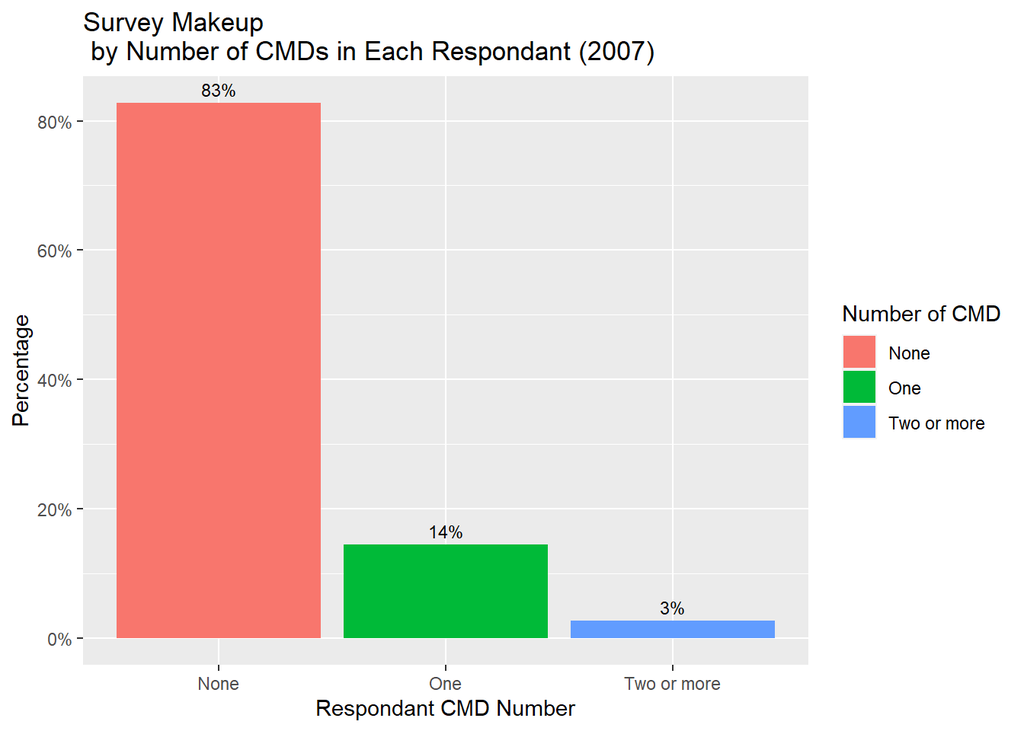

```r
# Number of Common Mental Disorders
ggplot(data = subset_pms07, aes(x = numcmd,
                          y = prop.table(stat(count)),
                          fill = numcmd,
                          label = scales::percent(prop.table(stat(count))))) +
    geom_bar() +
    geom_text(stat = 'count',
              position = position_dodge(.9),
              vjust = -0.5,
              size = 3) +
    scale_y_continuous(labels = scales::percent) +
    labs(title="Survey Makeup \n by Number of CMDs in Each Respondant (2007)",
       x = 'Respondant CMD Number',
       y = 'Percentage', fill = 'Number of CMD')
```

## 2.10 Region

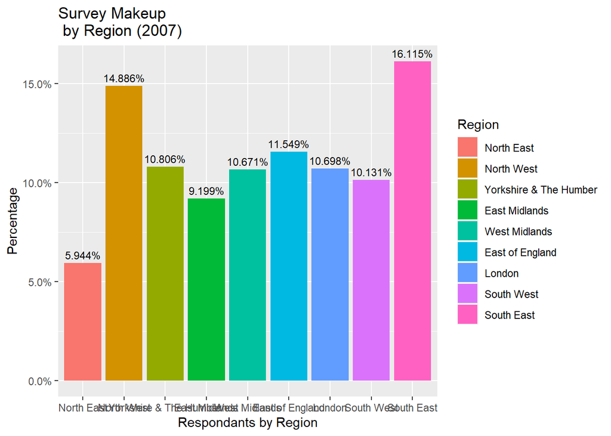

```r
# Region
ggplot(data = subset_pms07, aes(x = region,
                          y = prop.table(stat(count)),
                          fill = region,
                          label = scales::percent(prop.table(stat(count))))) +
    geom_bar() +
    geom_text(stat = 'count',
              position = position_dodge(.9),
              vjust = -0.5,
              size = 3) +
    scale_y_continuous(labels = scales::percent) +
    labs(title="Survey Makeup \n by Region (2007)",
       x = 'Respondants by Region',
       y = 'Percentage', fill = 'Region')
```

## 2.11 CMD Treatment

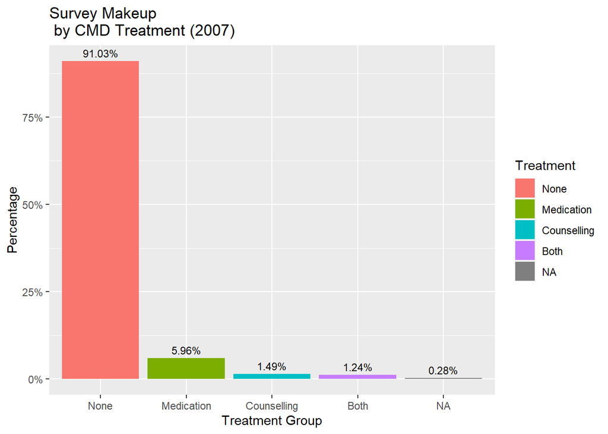

```r
# Treatment for CMDs
ggplot(data = subset_pms07, aes(x = treatment,
                          y = prop.table(stat(count)),
                          fill = treatment,
                          label = scales::percent(prop.table(stat(count))))) +
    geom_bar() +
    geom_text(stat = 'count',
              position = position_dodge(.9),
              vjust = -0.5,
              size = 3) +
    scale_y_continuous(labels = scales::percent) +
    labs(title="Survey Makeup \n by CMD Treatment (2007)",
       x = 'Treatment Group',
       y = 'Percentage', fill = 'Treatment')
```

## 2.12 Drug Use

77% of the sample responded with having never used any drug in their lifetime, and 22% indicated they had used some form of illegal drug int heir lifetime.

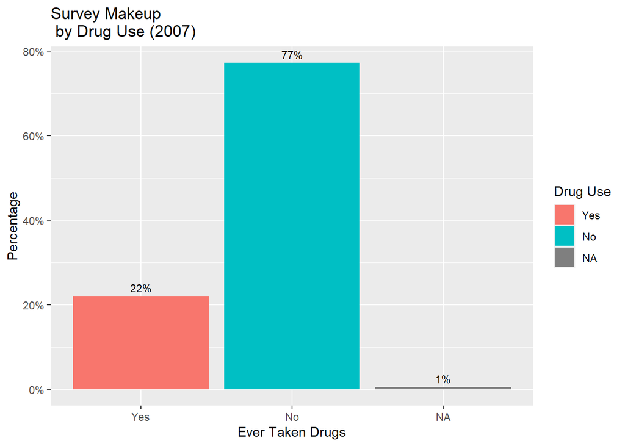

```r
# Ever Took Drugs
ggplot(data = subset_pms07, aes(x = evdrug,
                          y = prop.table(stat(count)),
                          fill = evdrug,
                          label = scales::percent(prop.table(stat(count))))) +
    geom_bar() +
    geom_text(stat = 'count',
              position = position_dodge(.9),
              vjust = -0.5,
              size = 3) +
    scale_y_continuous(labels = scales::percent) +
    labs(title="Survey Makeup \n by Drug Use (2007)",
       x = 'Ever Taken Drugs',
       y = 'Percentage', fill = 'Drug Use')
```

## 2.13 ‘Sex’

‘Sex’ = 57% identified as female, and 43% as male.

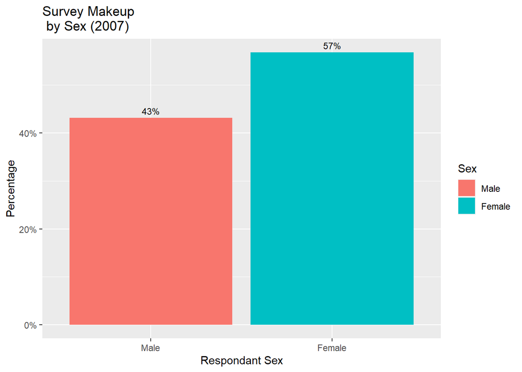

```r
# Sex
ggplot(data = subset_pms07, aes(x = sex,
                          y = prop.table(stat(count)),
                          fill = sex,
                          label = scales::percent(prop.table(stat(count))))) +
    geom_bar() +
    geom_text(stat = 'count',
              position = position_dodge(.9),
              vjust = -0.5,
              size = 3) +
    scale_y_continuous(labels = scales::percent) +
    labs(title="Survey Makeup \n by Sex (2007)",
       x = 'Respondant Sex',
       y = 'Percentage', fill = 'Sex')
```

# 3 Bivariate Exploration

## 3.1 CIS-R Score by Sex and Age

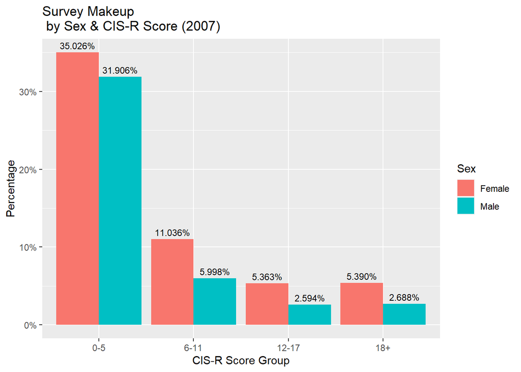

```r
# plot
subset_pms07 %>%
  filter(!is.na(cisrfour)) %>%
ggplot(aes(x = factor(cisrfour),
           y = prop.table(stat(count)),
           fill = fct_infreq(sex),
           label = scales::percent(prop.table(stat(count))))) +
  geom_bar(position = "dodge") +
  geom_text(stat = 'count',
            position = position_dodge(.9),
            vjust = -0.5,
            size = 3) +
  scale_y_continuous(labels = scales::percent) +
  labs(title="Survey Makeup \n by Sex & CIS-R Score (2007)",
       x = 'CIS-R Score Group',
       y = 'Percentage', fill = 'Sex')
```

```r
#table
subset_pms07 %>%
  select(sex, age10yrs, cisrfour) %>%
  tbl_summary(by = age10yrs,
              missing = "no") %>%
  add_p() %>%
  add_overall() %>%
  add_n() %>%
  bold_labels()
```

[output not shown]

[output not shown]

| **Characteristic** | **N** | **Overall**, N = 7,403<sup>1</sup> | **Don't know**, N = 0<sup>1</sup> | **16 to 24**, N = 568<sup>1</sup> | **25 to 34**, N = 1,035<sup>1</sup> | **35 to 44**, N = 1,413<sup>1</sup> | **45 to 54**, N = 1,130<sup>1</sup> | **55 to 64**, N = 1,279<sup>1</sup> | **65 to 74**, N = 1,028<sup>1</sup> | **75+**, N = 950<sup>1</sup> | **p-value** |
| --- | --- | --- | --- | --- | --- | --- | --- | --- | --- | --- | --- |
| sex | 7,403 |  |  |  |  |  |  |  |  |  |  |
| Male |  | 3,197 (43%) | 0 (NA%) | 271 (48%) | 414 (40%) | 613 (43%) | 495 (44%) | 573 (45%) | 462 (45%) | 369 (39%) |  |
| Female |  | 4,206 (57%) | 0 (NA%) | 297 (52%) | 621 (60%) | 800 (57%) | 635 (56%) | 706 (55%) | 566 (55%) | 581 (61%) |  |
| (D) CIS-R score in four groups | 7,403 |  |  |  |  |  |  |  |  |  |  |
| No answer/refused |  | 0 (0%) | 0 (NA%) | 0 (0%) | 0 (0%) | 0 (0%) | 0 (0%) | 0 (0%) | 0 (0%) | 0 (0%) |  |
| Don't know |  | 0 (0%) | 0 (NA%) | 0 (0%) | 0 (0%) | 0 (0%) | 0 (0%) | 0 (0%) | 0 (0%) | 0 (0%) |  |
| Missing data |  | 0 (0%) | 0 (NA%) | 0 (0%) | 0 (0%) | 0 (0%) | 0 (0%) | 0 (0%) | 0 (0%) | 0 (0%) |  |
| Proxy |  | 0 (0%) | 0 (NA%) | 0 (0%) | 0 (0%) | 0 (0%) | 0 (0%) | 0 (0%) | 0 (0%) | 0 (0%) |  |
| Item not applicable |  | 0 (0%) | 0 (NA%) | 0 (0%) | 0 (0%) | 0 (0%) | 0 (0%) | 0 (0%) | 0 (0%) | 0 (0%) |  |
| 0-5 |  | 4,955 (67%) | 0 (NA%) | 363 (64%) | 657 (63%) | 905 (64%) | 687 (61%) | 881 (69%) | 759 (74%) | 703 (74%) |  |
| 6-11 |  | 1,261 (17%) | 0 (NA%) | 100 (18%) | 174 (17%) | 258 (18%) | 198 (18%) | 211 (16%) | 160 (16%) | 160 (17%) |  |
| 12-17 |  | 589 (8.0%) | 0 (NA%) | 44 (7.7%) | 103 (10.0%) | 119 (8.4%) | 102 (9.0%) | 94 (7.3%) | 73 (7.1%) | 54 (5.7%) |  |
| 18+ |  | 598 (8.1%) | 0 (NA%) | 61 (11%) | 101 (9.8%) | 131 (9.3%) | 143 (13%) | 93 (7.3%) | 36 (3.5%) | 33 (3.5%) |  |

<sup>*1*</sup> n (%)

Rates of CMD also varied by age group: those aged 75 and over were the least likely to have a CMD. The rate among women peaked in the 45-54 age group, with a quarter meeting the criteria for at least one CMD. Among men, the rate was highest in 25-54 year olds.

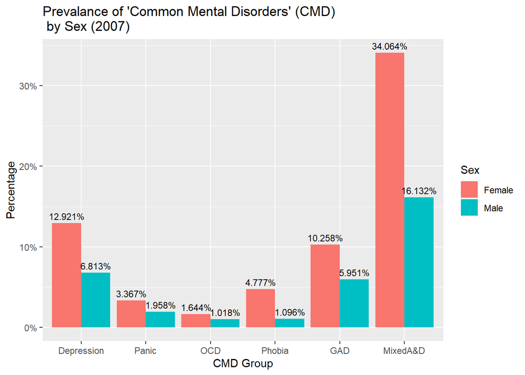

```r
# CMD condition by sex - NAs dropped and sorted by frequency
subset_pms07 %>%
  filter(!is.na(cmdgroup)) %>%
ggplot(aes(x = factor(cmdgroup),
           y = prop.table(stat(count)),
           fill = fct_infreq(sex),
           label = scales::percent(prop.table(stat(count))))) +
  geom_bar(position = "dodge") +
  geom_text(stat = 'count',
            position = position_dodge(.9),
            vjust = -0.5,
            size = 3) +
  scale_y_continuous(labels = scales::percent) +
  labs(title="Prevalance of 'Common Mental Disorders' (CMD) \n by Sex (2007)",
       x = 'CMD Group',
       y = 'Percentage', fill = 'Sex')
```

## 3.2 CMD Group by CIS-R Score

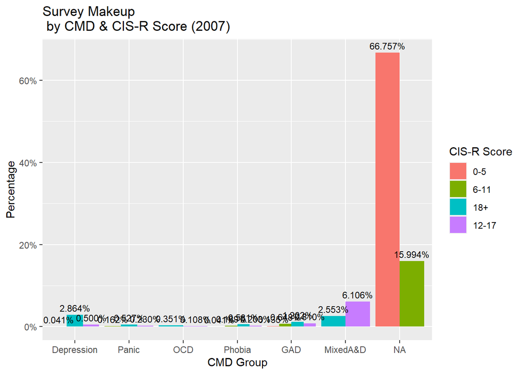

```r
# plot
subset_pms07 %>%
  filter(!is.na(cisrfour)) %>%
ggplot(aes(x = factor(cmdgroup),
           y = prop.table(stat(count)),
           fill = fct_infreq(cisrfour),
           label = scales::percent(prop.table(stat(count))))) +
  geom_bar(position = "dodge") +
  geom_text(stat = 'count',
            position = position_dodge(.9),
            vjust = -0.5,
            size = 3) +
  scale_y_continuous(labels = scales::percent) +
  labs(title="Survey Makeup \n by CMD & CIS-R Score (2007)",
       x = 'CMD Group',
       y = 'Percentage', fill = 'CIS-R Score')
```

## 3.3 Ethnicity

Rates of having at least one CMD were higher for white, black and South Asian women than for white, black and South Asian men respectively. The greatest difference was among South Asian adults.The number of South Asian women in the sample was small, so while the differences were pronounced they were only significant for CMD as a whole, and generalised anxiety disorder and panic disorder.

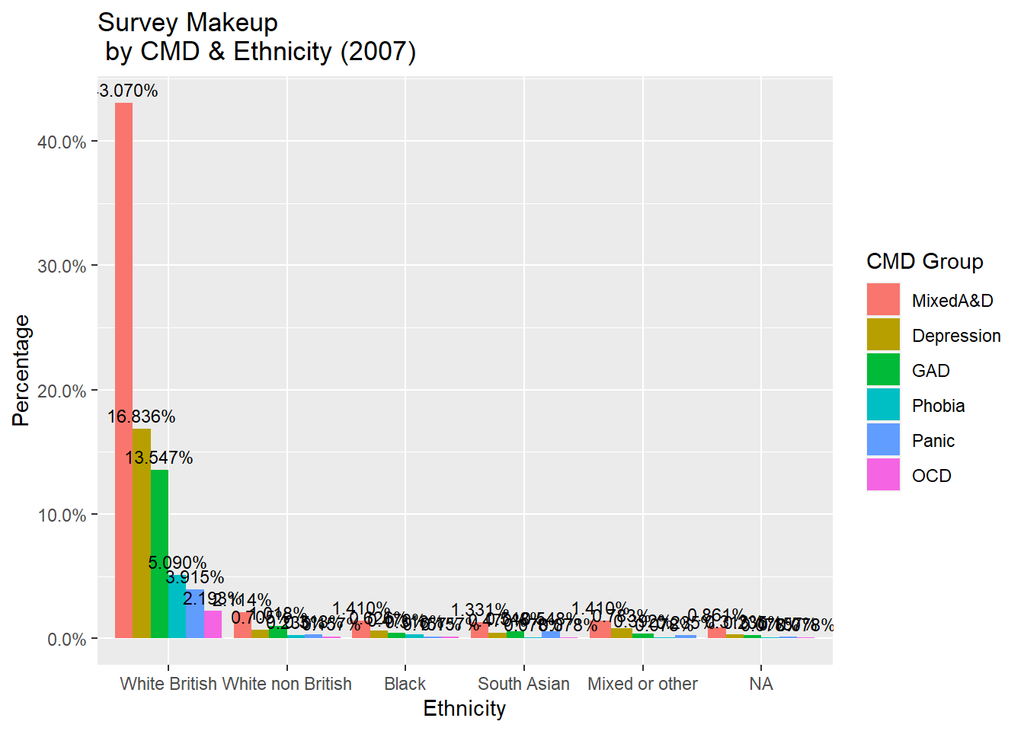

```r
subset_pms07 %>%
  filter(!is.na(cmdgroup)) %>%
ggplot(aes(x = factor(ethnicgrp),
           y = prop.table(stat(count)),
           fill = fct_infreq(cmdgroup),
           label = scales::percent(prop.table(stat(count))))) +
  geom_bar(position = "dodge") +
  geom_text(stat = 'count',
            position = position_dodge(.9),
            vjust = -0.5,
            size = 3) +
  scale_y_continuous(labels = scales::percent) +
  labs(title="Survey Makeup \n by CMD & Ethnicity (2007)",
       x = 'Ethnicity',
       y = 'Percentage', fill = 'CMD Group')
```

## 3.4 Marital status

Women across all marital status categories were more likely than their male counterparts to have CMD, except for divorced people, in whom the prevalence for men and women was very similar. Among men, those currently divorced had the greatest likelihood of having CMD.

```r
#cmd by ethnicity and sex
subset_pms07 %>%
  select(sex, ethnicgrp, cmdgroup) %>%
  tbl_summary(by = ethnicgrp,
              missing = "no") %>%
  add_p() %>%
  add_overall() %>%
  add_n() %>%
  bold_labels()
```

```
## 50 observations missing `ethnicgrp` have been removed. To include these observations, use `forcats::fct_explicit_na()` on `ethnicgrp` column before passing to `tbl_summary()`.
```

[output not shown]

| **Characteristic** | **N** | **Overall**, N = 7,353<sup>1</sup> | **White British**, N = 6,499<sup>1</sup> | **White non British**, N = 308<sup>1</sup> | **Black**, N = 188<sup>1</sup> | **South Asian**, N = 199<sup>1</sup> | **Mixed or other**, N = 159<sup>1</sup> | **p-value**<sup>2</sup> |
| --- | --- | --- | --- | --- | --- | --- | --- | --- |
| sex | 7,353 |  |  |  |  |  |  | 0.014 |
| Male |  | 3,171 (43%) | 2,787 (43%) | 126 (41%) | 77 (41%) | 109 (55%) | 72 (45%) |  |
| Female |  | 4,182 (57%) | 3,712 (57%) | 182 (59%) | 111 (59%) | 90 (45%) | 87 (55%) |  |
| cmdgroup | 1,255 |  |  |  |  |  |  |  |
| Depression |  | 248 (20%) | 215 (20%) | 9 (16%) | 8 (20%) | 6 (15%) | 10 (27%) |  |
| Panic |  | 66 (5.3%) | 50 (4.6%) | 4 (6.9%) | 2 (5.0%) | 7 (18%) | 3 (8.1%) |  |
| OCD |  | 33 (2.6%) | 28 (2.6%) | 2 (3.4%) | 2 (5.0%) | 1 (2.6%) | 0 (0%) |  |
| Phobia |  | 74 (5.9%) | 65 (6.0%) | 3 (5.2%) | 4 (10%) | 1 (2.6%) | 1 (2.7%) |  |
| GAD |  | 204 (16%) | 173 (16%) | 13 (22%) | 6 (15%) | 7 (18%) | 5 (14%) |  |
| MixedA&D |  | 630 (50%) | 550 (51%) | 27 (47%) | 18 (45%) | 17 (44%) | 18 (49%) |  |

<sup>*1*</sup> n (%) <sup>*2*</sup> Pearson's Chi-squared test

```r
#cmd by marital status and sex
subset_pms07 %>%
  select(sex, maritalstat, cmdgroup) %>%
  tbl_summary(by = maritalstat,
              missing = "no") %>%
  add_p() %>%
  add_overall() %>%
  add_n() %>%
  bold_labels()
```

[output not shown]

| **Characteristic** | **N** | **Overall**, N = 7,403<sup>1</sup> | **Married**, N = 3,519<sup>1</sup> | **Cohabiting**, N = 614<sup>1</sup> | **Single**, N = 1,428<sup>1</sup> | **Widowed**, N = 949<sup>1</sup> | **Divorced**, N = 670<sup>1</sup> | **Separated**, N = 223<sup>1</sup> | **p-value**<sup>2</sup> |
| --- | --- | --- | --- | --- | --- | --- | --- | --- | --- |
| sex | 7,403 |  |  |  |  |  |  |  | <0.001 |
| Male |  | 3,197 (43%) | 1,673 (48%) | 279 (45%) | 700 (49%) | 234 (25%) | 232 (35%) | 79 (35%) |  |
| Female |  | 4,206 (57%) | 1,846 (52%) | 335 (55%) | 728 (51%) | 715 (75%) | 438 (65%) | 144 (65%) |  |
| cmdgroup | 1,277 |  |  |  |  |  |  |  |  |
| Depression |  | 252 (20%) | 75 (16%) | 10 (8.8%) | 73 (23%) | 33 (23%) | 46 (26%) | 15 (25%) |  |
| Panic |  | 68 (5.3%) | 23 (5.0%) | 8 (7.0%) | 19 (6.0%) | 6 (4.1%) | 9 (5.1%) | 3 (5.0%) |  |
| OCD |  | 34 (2.7%) | 9 (1.9%) | 3 (2.6%) | 13 (4.1%) | 2 (1.4%) | 3 (1.7%) | 4 (6.7%) |  |
| Phobia |  | 75 (5.9%) | 22 (4.8%) | 10 (8.8%) | 22 (6.9%) | 7 (4.8%) | 11 (6.2%) | 3 (5.0%) |  |
| GAD |  | 207 (16%) | 80 (17%) | 21 (18%) | 44 (14%) | 24 (17%) | 32 (18%) | 6 (10%) |  |
| MixedA&D |  | 641 (50%) | 253 (55%) | 62 (54%) | 147 (46%) | 73 (50%) | 77 (43%) | 29 (48%) |  |

<sup>*1*</sup> n (%) <sup>*2*</sup> Pearson's Chi-squared test

## 3.5 Equivalised household income

```r
# cmd by hhold and sex
subset_pms07 %>%
  select(sex, cmdgroup, eqhouseinc) %>%
  tbl_summary(by = eqhouseinc,
              missing = "no") %>%
  add_p() %>%
  add_overall() %>%
  add_n() %>%
  bold_labels()
```

```
## 1531 observations missing `eqhouseinc` have been removed. To include these observations, use `forcats::fct_explicit_na()` on `eqhouseinc` column before passing to `tbl_summary()`.
```

[output not shown]

| **Characteristic** | **N** | **Overall**, N = 5,872<sup>1</sup> | **Highest**, N = 1,191<sup>1</sup> | **2nd**, N = 1,151<sup>1</sup> | **3rd**, N = 1,242<sup>1</sup> | **4th**, N = 1,122<sup>1</sup> | **Lowest**, N = 1,166<sup>1</sup> | **p-value**<sup>2</sup> |
| --- | --- | --- | --- | --- | --- | --- | --- | --- |
| sex | 5,872 |  |  |  |  |  |  | <0.001 |
| Male |  | 2,555 (44%) | 629 (53%) | 549 (48%) | 509 (41%) | 446 (40%) | 422 (36%) |  |
| Female |  | 3,317 (56%) | 562 (47%) | 602 (52%) | 733 (59%) | 676 (60%) | 744 (64%) |  |
| cmdgroup | 1,020 |  |  |  |  |  |  |  |
| Depression |  | 210 (21%) | 21 (14%) | 28 (20%) | 31 (15%) | 47 (22%) | 83 (27%) |  |
| Panic |  | 57 (5.6%) | 10 (6.7%) | 6 (4.3%) | 4 (2.0%) | 15 (7.0%) | 22 (7.1%) |  |
| OCD |  | 26 (2.5%) | 5 (3.3%) | 1 (0.7%) | 3 (1.5%) | 11 (5.2%) | 6 (1.9%) |  |
| Phobia |  | 57 (5.6%) | 8 (5.3%) | 9 (6.4%) | 10 (4.9%) | 12 (5.6%) | 18 (5.8%) |  |
| GAD |  | 157 (15%) | 27 (18%) | 27 (19%) | 30 (15%) | 30 (14%) | 43 (14%) |  |
| MixedA&D |  | 513 (50%) | 79 (53%) | 70 (50%) | 127 (62%) | 98 (46%) | 139 (45%) |  |

<sup>*1*</sup> n (%) <sup>*2*</sup> Pearson's Chi-squared test

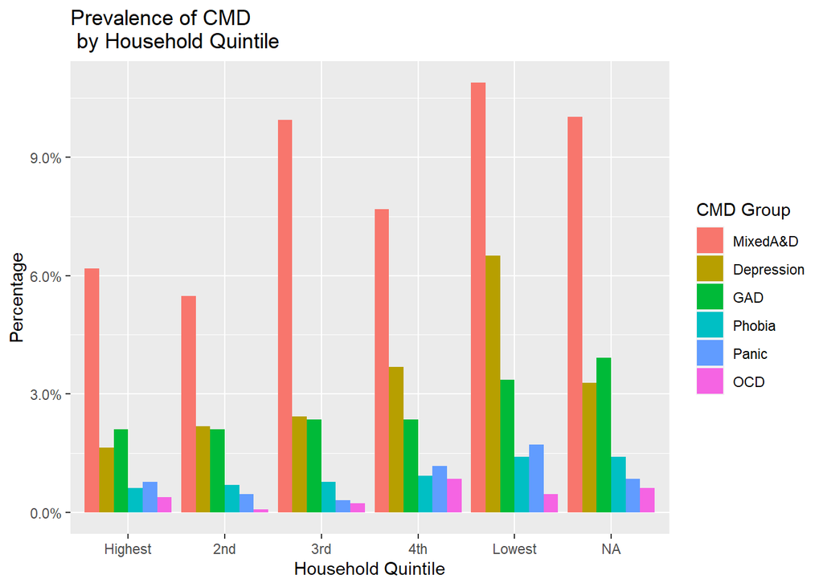

```r
# C<D by sex and household quintile
subset_pms07 %>%
  filter(!is.na(cmdgroup)) %>%
ggplot(aes(x = factor(eqhouseinc),
           y = prop.table(stat(count)),
           fill = fct_infreq(cmdgroup),
           label = scales::percent(prop.table(stat(count))))) +
  geom_bar(position = "dodge") +
  scale_y_continuous(labels = scales::percent) +
  labs(title="Prevalence of CMD \n by Household Quintile",
       x = 'Household Quintile',
       y = 'Percentage', fill = 'CMD Group')
```

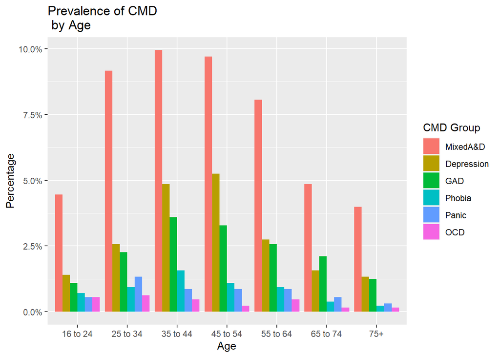

```r
# CMD by age
subset_pms07 %>%
  filter(!is.na(cmdgroup)) %>%
ggplot(aes(x = factor(age10yrs),
           y = prop.table(stat(count)),
           fill = fct_infreq(cmdgroup),
           label = scales::percent(prop.table(stat(count))))) +
  geom_bar(position = "dodge") +
  scale_y_continuous(labels = scales::percent) +
  labs(title="Prevalence of CMD \n by Age",
       x = 'Age',
       y = 'Percentage', fill = 'CMD Group')
```

```r
# cmd by age
subset_pms07 %>%
  select(cmdgroup, age10yrs) %>%
  tbl_summary(by = age10yrs,
              missing = "no") %>%
  add_p() %>%
  add_overall() %>%
  add_n() %>%
  bold_labels()
```

[output not shown]

| **Characteristic** | **N** | **Overall**, N = 7,403<sup>1</sup> | **Don't know**, N = 0<sup>1</sup> | **16 to 24**, N = 568<sup>1</sup> | **25 to 34**, N = 1,035<sup>1</sup> | **35 to 44**, N = 1,413<sup>1</sup> | **45 to 54**, N = 1,130<sup>1</sup> | **55 to 64**, N = 1,279<sup>1</sup> | **65 to 74**, N = 1,028<sup>1</sup> | **75+**, N = 950<sup>1</sup> | **p-value** |
| --- | --- | --- | --- | --- | --- | --- | --- | --- | --- | --- | --- |
| cmdgroup | 1,277 |  |  |  |  |  |  |  |  |  |  |
| Depression |  | 252 (20%) | 0 (NA%) | 18 (16%) | 33 (15%) | 62 (23%) | 67 (26%) | 35 (18%) | 20 (16%) | 17 (18%) |  |
| Panic |  | 68 (5.3%) | 0 (NA%) | 7 (6.2%) | 17 (7.9%) | 11 (4.0%) | 11 (4.2%) | 11 (5.5%) | 7 (5.7%) | 4 (4.3%) |  |
| OCD |  | 34 (2.7%) | 0 (NA%) | 7 (6.2%) | 8 (3.7%) | 6 (2.2%) | 3 (1.1%) | 6 (3.0%) | 2 (1.6%) | 2 (2.2%) |  |
| Phobia |  | 75 (5.9%) | 0 (NA%) | 9 (8.0%) | 12 (5.6%) | 20 (7.4%) | 14 (5.4%) | 12 (6.0%) | 5 (4.1%) | 3 (3.2%) |  |
| GAD |  | 207 (16%) | 0 (NA%) | 14 (12%) | 29 (13%) | 46 (17%) | 42 (16%) | 33 (16%) | 27 (22%) | 16 (17%) |  |
| MixedA&D |  | 641 (50%) | 0 (NA%) | 57 (51%) | 117 (54%) | 127 (47%) | 124 (48%) | 103 (52%) | 62 (50%) | 51 (55%) |  |

<sup>*1*</sup> n (%)

## 3.6 Treatment

Treatment by CIS-R score A CIS-R score of 18 or more indicated a severity of neurotic symptoms in the past week likely to warrant treatment: however only a third of this group were in receipt of any medication or counselling at the time of interview. Among those with a score between 12 and 17, 17% were receiving treatment.

Types of treatment A quarter of adults with a CMD in the past week were in receipt of treatment for an emotional or mental problem. This was mostly in the form of medication: less than 20% of adults with a neurotic disorder were taking psychoactive medication only, Less than 5% were in receipt of counselling or therapy, and 5% were in receipt of both (medication and counselling or therapy)

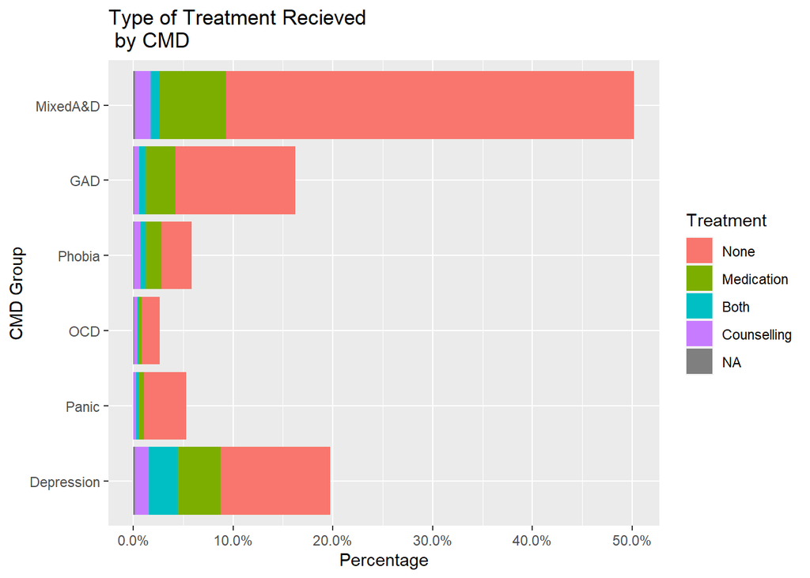

```r
# treatment recieved by CMD
subset_pms07 %>%
  filter(!is.na(cmdgroup)) %>%
ggplot(aes(x = factor(cmdgroup),
           y = prop.table(stat(count)),
           fill = fct_infreq(treatment),
           label = scales::percent(prop.table(stat(count))))) +
  geom_bar(position='stack') +
  coord_flip() +
  scale_y_continuous(labels = scales::percent) +
  labs(title="Type of Treatment Recieved \n by CMD",
       x = 'CMD Group',
       y = 'Percentage', fill = 'Treatment')
```

```r
subset_pms07 %>%
  select(sex, age10yrs, cmdgroup, treatment, employstat) %>%
  tbl_summary(by = cmdgroup,
              missing = "no") %>%
  add_p() %>%
  add_overall() %>%
  add_n() %>%
  bold_labels()
```

```
## 6126 observations missing `cmdgroup` have been removed. To include these observations, use `forcats::fct_explicit_na()` on `cmdgroup` column before passing to `tbl_summary()`.
```

[output not shown]

[output not shown]

[output not shown]

| **Characteristic** | **N** | **Overall**, N = 1,277<sup>1</sup> | **Depression**, N = 252<sup>1</sup> | **Panic**, N = 68<sup>1</sup> | **OCD**, N = 34<sup>1</sup> | **Phobia**, N = 75<sup>1</sup> | **GAD**, N = 207<sup>1</sup> | **MixedA&D**, N = 641<sup>1</sup> | **p-value**<sup>2</sup> |
| --- | --- | --- | --- | --- | --- | --- | --- | --- | --- |
| sex | 1,277 |  |  |  |  |  |  |  | 0.087 |
| Male |  | 421 (33%) | 87 (35%) | 25 (37%) | 13 (38%) | 14 (19%) | 76 (37%) | 206 (32%) |  |
| Female |  | 856 (67%) | 165 (65%) | 43 (63%) | 21 (62%) | 61 (81%) | 131 (63%) | 435 (68%) |  |
| age10yrs | 1,277 |  |  |  |  |  |  |  |  |
| Don't know |  | 0 (0%) | 0 (0%) | 0 (0%) | 0 (0%) | 0 (0%) | 0 (0%) | 0 (0%) |  |
| 16 to 24 |  | 112 (8.8%) | 18 (7.1%) | 7 (10%) | 7 (21%) | 9 (12%) | 14 (6.8%) | 57 (8.9%) |  |
| 25 to 34 |  | 216 (17%) | 33 (13%) | 17 (25%) | 8 (24%) | 12 (16%) | 29 (14%) | 117 (18%) |  |
| 35 to 44 |  | 272 (21%) | 62 (25%) | 11 (16%) | 6 (18%) | 20 (27%) | 46 (22%) | 127 (20%) |  |
| 45 to 54 |  | 261 (20%) | 67 (27%) | 11 (16%) | 3 (8.8%) | 14 (19%) | 42 (20%) | 124 (19%) |  |
| 55 to 64 |  | 200 (16%) | 35 (14%) | 11 (16%) | 6 (18%) | 12 (16%) | 33 (16%) | 103 (16%) |  |
| 65 to 74 |  | 123 (9.6%) | 20 (7.9%) | 7 (10%) | 2 (5.9%) | 5 (6.7%) | 27 (13%) | 62 (9.7%) |  |
| 75+ |  | 93 (7.3%) | 17 (6.7%) | 4 (5.9%) | 2 (5.9%) | 3 (4.0%) | 16 (7.7%) | 51 (8.0%) |  |
| treatment | 1,270 |  |  |  |  |  |  |  |  |
| None |  | 931 (73%) | 140 (56%) | 54 (79%) | 23 (70%) | 39 (53%) | 153 (74%) | 522 (82%) |  |
| Medication |  | 208 (16%) | 55 (22%) | 7 (10%) | 3 (9.1%) | 20 (27%) | 38 (18%) | 85 (13%) |  |
| Counselling |  | 61 (4.8%) | 18 (7.2%) | 4 (5.9%) | 4 (12%) | 8 (11%) | 7 (3.4%) | 20 (3.1%) |  |
| Both |  | 70 (5.5%) | 37 (15%) | 3 (4.4%) | 3 (9.1%) | 7 (9.5%) | 8 (3.9%) | 12 (1.9%) |  |
| employstat | 1,277 |  |  |  |  |  |  |  |  |
| Employed |  | 581 (45%) | 85 (34%) | 34 (50%) | 14 (41%) | 33 (44%) | 101 (49%) | 314 (49%) |  |
| Unpaid Family Work |  | 4 (0.3%) | 0 (0%) | 0 (0%) | 0 (0%) | 1 (1.3%) | 1 (0.5%) | 2 (0.3%) |  |
| Unemployed |  | 48 (3.8%) | 10 (4.0%) | 4 (5.9%) | 4 (12%) | 1 (1.3%) | 11 (5.3%) | 18 (2.8%) |  |
| Economically inactive |  | 644 (50%) | 157 (62%) | 30 (44%) | 16 (47%) | 40 (53%) | 94 (45%) | 307 (48%) |  |

<sup>*1*</sup> n (%) <sup>*2*</sup> Pearson's Chi-squared test

## 3.7 Drug use and CMD

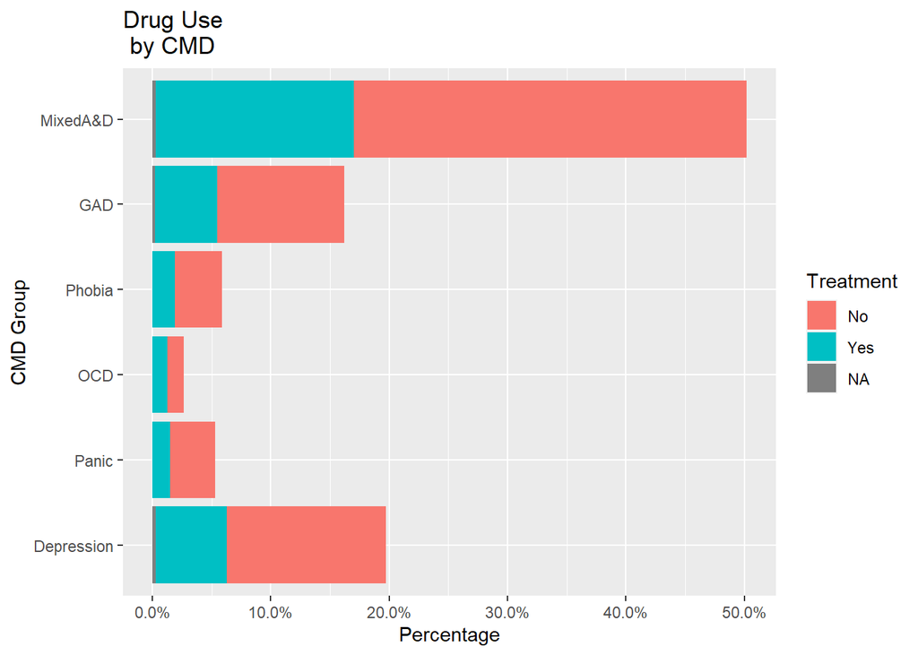

```r
# treatment recieved by CMD
subset_pms07 %>%
  filter(!is.na(cmdgroup)) %>%
ggplot(aes(x = factor(cmdgroup),
           y = prop.table(stat(count)),
           fill = fct_infreq(evdrug),
           label = scales::percent(prop.table(stat(count))))) +
  geom_bar(position='stack') +
  coord_flip() +
  scale_y_continuous(labels = scales::percent) +
  labs(title="Drug Use \n by CMD",
       x = 'CMD Group',
       y = 'Percentage', fill = 'Treatment')
```

```r
subset_pms07 %>%
  select(cmdgroup, evdrug) %>%
  tbl_summary(by = evdrug,
              missing = "no") %>%
  add_p() %>%
  add_overall() %>%
  add_n() %>%
  bold_labels()
```

```
## 46 observations missing `evdrug` have been removed. To include these observations, use `forcats::fct_explicit_na()` on `evdrug` column before passing to `tbl_summary()`.
```

| **Characteristic** | **N** | **Overall**, N = 7,357<sup>1</sup> | **Yes**, N = 1,637<sup>1</sup> | **No**, N = 5,720<sup>1</sup> | **p-value**<sup>2</sup> |
| --- | --- | --- | --- | --- | --- |
| cmdgroup | 1,266 |  |  |  | 0.5 |
| Depression |  | 248 (20%) | 76 (18%) | 172 (20%) |  |
| Panic |  | 68 (5.4%) | 19 (4.6%) | 49 (5.8%) |  |
| OCD |  | 34 (2.7%) | 16 (3.9%) | 18 (2.1%) |  |
| Phobia |  | 75 (5.9%) | 24 (5.8%) | 51 (6.0%) |  |
| GAD |  | 204 (16%) | 67 (16%) | 137 (16%) |  |
| MixedA&D |  | 637 (50%) | 213 (51%) | 424 (50%) |  |

<sup>*1*</sup> n (%) <sup>*2*</sup> Pearson's Chi-squared test

## 3.8 Use of community care services

All respondents were asked about community and day care services used in the past year. These included contact with a psychiatrist, psychologist, community nurse services, a social worker, self help or support groups, home helps, outreach workers and a community day care centre. Day care centres asked about included community mental health centre, day activity centre, and sheltered workshop.

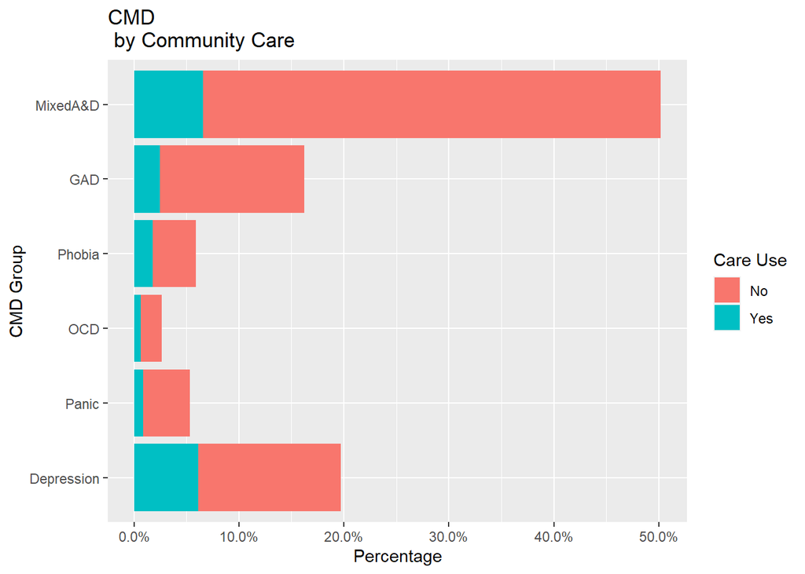

```r
# CMD by community care use
subset_pms07 %>%
  filter(!is.na(cmdgroup)) %>%
ggplot(aes(x = factor(cmdgroup),
           y = prop.table(stat(count)),
           fill = fct_infreq(commcareyr),
           label = scales::percent(prop.table(stat(count))))) +
  geom_bar(position='stack') +
  coord_flip() +
  scale_y_continuous(labels = scales::percent) +
  labs(title="CMD \n by Community Care",
       x = 'CMD Group',
       y = 'Percentage', fill = 'Care Use')
```

```r
# cmd by commcare
subset_pms07 %>%
  select(sex, commcareyr, cmdgroup) %>%
  tbl_summary(by = cmdgroup,
              missing = "no") %>%
  add_p() %>%
  add_overall() %>%
  add_n() %>%
  bold_labels()
```

```
## 6126 observations missing `cmdgroup` have been removed. To include these observations, use `forcats::fct_explicit_na()` on `cmdgroup` column before passing to `tbl_summary()`.
```

| **Characteristic** | **N** | **Overall**, N = 1,277<sup>1</sup> | **Depression**, N = 252<sup>1</sup> | **Panic**, N = 68<sup>1</sup> | **OCD**, N = 34<sup>1</sup> | **Phobia**, N = 75<sup>1</sup> | **GAD**, N = 207<sup>1</sup> | **MixedA&D**, N = 641<sup>1</sup> | **p-value**<sup>2</sup> |
| --- | --- | --- | --- | --- | --- | --- | --- | --- | --- |
| sex | 1,277 |  |  |  |  |  |  |  | 0.087 |
| Male |  | 421 (33%) | 87 (35%) | 25 (37%) | 13 (38%) | 14 (19%) | 76 (37%) | 206 (32%) |  |
| Female |  | 856 (67%) | 165 (65%) | 43 (63%) | 21 (62%) | 61 (81%) | 131 (63%) | 435 (68%) |  |
| commcareyr | 1,277 | 236 (18%) | 78 (31%) | 11 (16%) | 8 (24%) | 23 (31%) | 32 (15%) | 84 (13%) | <0.001 |

<sup>*1*</sup> n (%) <sup>*2*</sup> Pearson's Chi-squared test

## 3.9 Employment Status and Education

More females than males reported both being in employment, or alternativly economically inactive, than men. Also of note is the high rates of mixed anxiety and depression, and depression among both male and females living within the lower income households. Of all adults employed, the common mental disorder most reported was mixed anxirty and depression. Of those adults who reported being unemployed, mixed anxiety and depressedm followed by generalised anxiety disorder were most reported. Of those adults who reported as economically inactive, the most common disorder reported was mixed anxiety and depression, followed by depression,

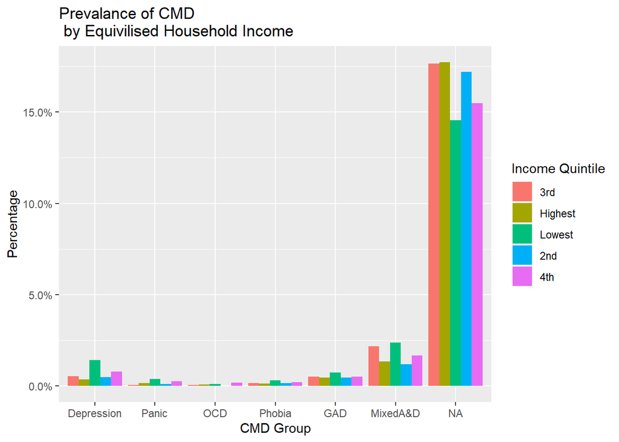

```r
# cmd by eq hhold income
subset_pms07 %>%
  filter(!is.na(eqhouseinc)) %>%
  ggplot(aes(x = factor(cmdgroup),
             y = prop.table(stat(count)),
             fill = fct_infreq(eqhouseinc),
             label = scales::percent(prop.table(stat(count))))) +
  geom_bar(position='dodge') +
  scale_y_continuous(labels = scales::percent) +
  labs(title="Prevalance of CMD \n by Equivilised Household Income",
       x = 'CMD Group',
       y = 'Percentage', fill = 'Income Quintile')
```

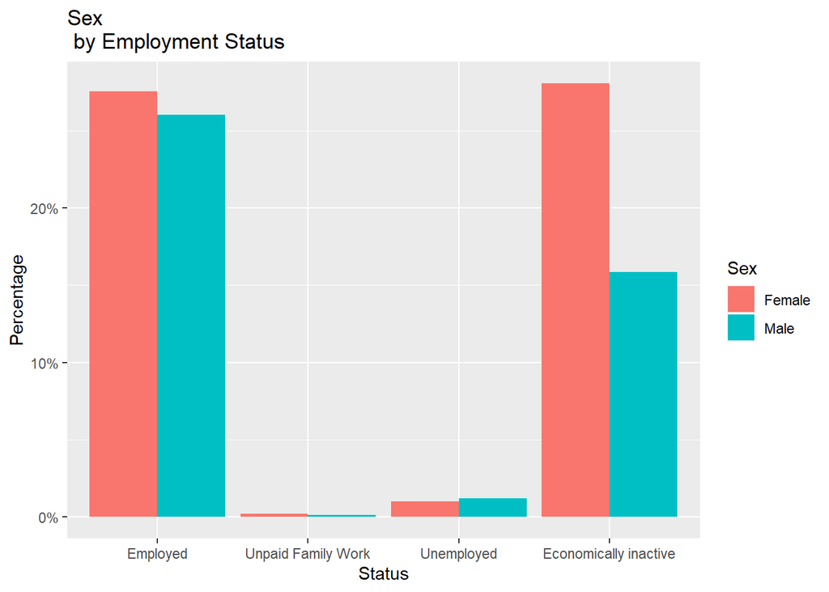

```r
# sex by employ status
subset_pms07 %>%
  filter(!is.na(sex)) %>%
  ggplot(aes(x = factor(employstat),
             y = prop.table(stat(count)),
             fill = fct_infreq(sex),
             label = scales::percent(prop.table(stat(count))))) +
  geom_bar(position='dodge') +
  scale_y_continuous(labels = scales::percent) +
  labs(title="Sex \n by Employment Status",
       x = 'Status',
       y = 'Percentage', fill = 'Sex')
```

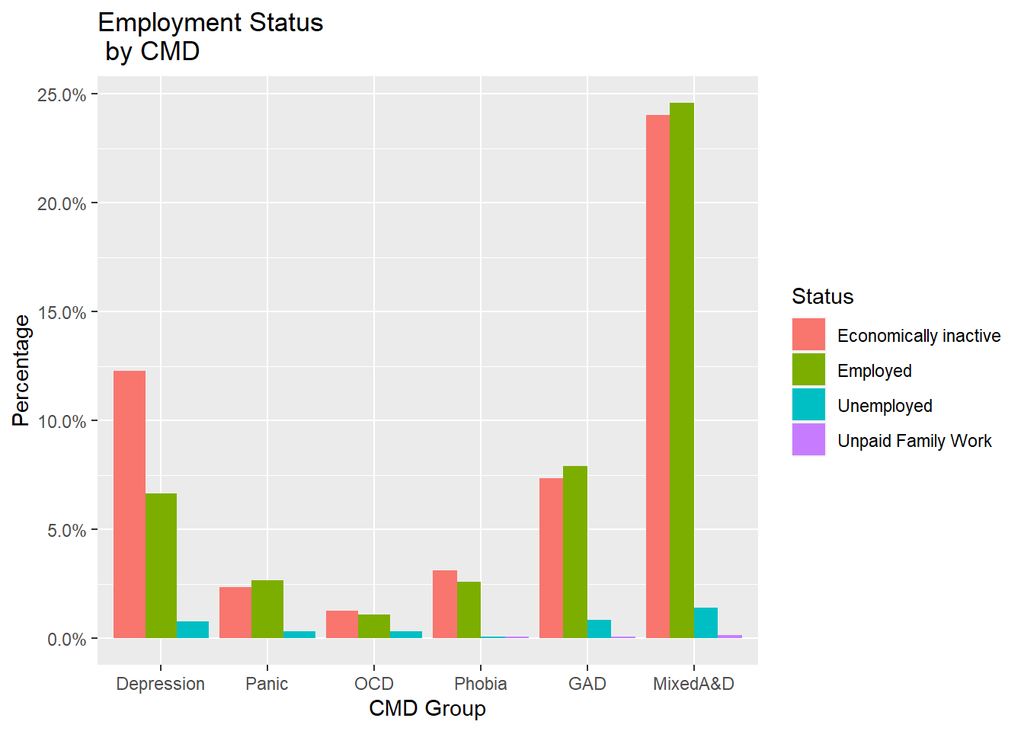

```r
# cmd by employment
# treatment recieved by CMD
subset_pms07 %>%
  filter(!is.na(cmdgroup)) %>%
  ggplot(aes(x = factor(cmdgroup),
             y = prop.table(stat(count)),
             fill = fct_infreq(employstat),
             label = scales::percent(prop.table(stat(count))))) +
  geom_bar(position='dodge') +
  scale_y_continuous(labels = scales::percent) +
  labs(title="Employment Status \n by CMD",
       x = 'CMD Group',
       y = 'Percentage', fill = 'Status')
```

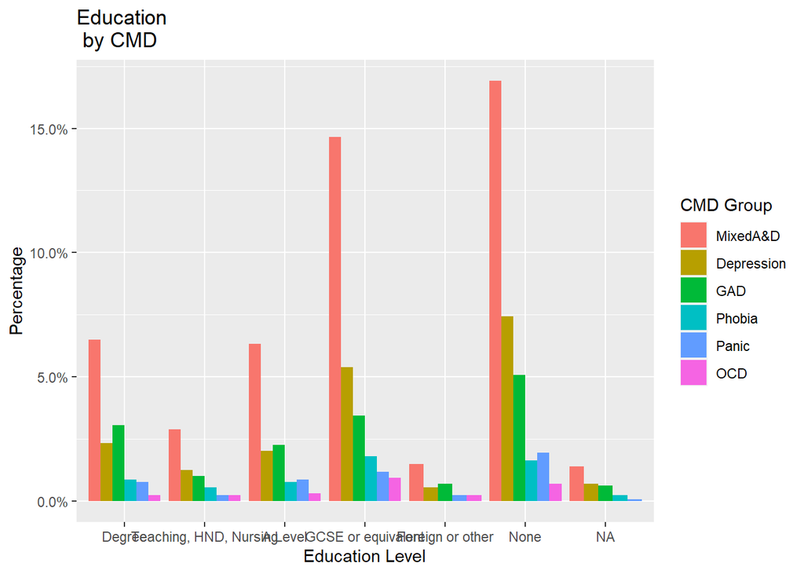

```r
# CMD by education
subset_pms07 %>%
  filter(!is.na(cmdgroup)) %>%
  ggplot(aes(x = factor(hiqual),
             y = prop.table(stat(count)),
             fill = fct_infreq(cmdgroup),
             label = scales::percent(prop.table(stat(count))))) +
  geom_bar(position='dodge') +
  scale_y_continuous(labels = scales::percent) +
  labs(title="Education \n by CMD",
       x = 'Education Level',
       y = 'Percentage', fill = 'CMD Group')
```

```r
# cmd by hhold and sex
#subset_pms07 %>%
#  select(sex, cmdgroup, eqhouseinc) %>%
#  tbl_summary(by = eqhouseinc,
#              missing = "no") %>%
#  add_overall() %>%
#  add_n() %>%
#  bold_labels()

# cmd by region and sex
#subset_pms07 %>%
#  select(sex, region, cmdgroup) %>%
#  tbl_summary(by = region,
#              missing = "no") %>%
#  add_overall() %>%
#  add_n() %>%
#  bold_labels()

# cmd by sex and employment
#subset_pms07 %>%
#  select(sex, employstat, cmdgroup) %>%
#  tbl_summary(by = employstat,
#              missing = "no") %>%
#  add_overall() %>%
#  add_n() %>%
#  bold_labels()

# cmd by sex and qual
#subset_pms07 %>%
#  select(sex, hiqual, cmdgroup) %>%
#  tbl_summary(by = hiqual,
#              missing = "no") %>%
#  add_overall() %>%
#  add_n() %>%
#  bold_labels()
```

# 4 Issues

1. NAs are still appearing = I did try to split these categories in NAs and ‘None’, but in the original variable levels, Missing is coded along with ‘Did not answer’, ‘proxy’ etc, so I couldn’t split into seperate None or NA groups. - Wondering what the best way to manage this is? Especially for tables, as with plots I can seem to drop NAs.
2. A little thing, but my y axis is %, I can’t figure out how to make it go to 100%?
3. Attaching cleaned variables to the subset = tidyverse way half worked - it did create the variablea dn they were viable in the df, but when I tried to call them even in a plot or table, there was an Error: does not exist. Weird.